# Hypothesis: Gender, Race, and Occupation Type have an impact on predicting unemployment in a specific US County

# Data Visualizations

### Scatter Line - Poverty % vs Unemployment

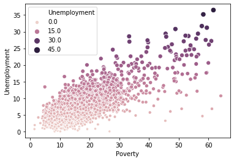

```python
sns.scatterplot(data=df_clean, x="Poverty", y="Unemployment", size = 'Unemployment', hue = 'Unemployment')
```

Counties w/ higher Poverty % tend to have a higher Unemployment rate

### Scatterplot - Income vs Unemployment

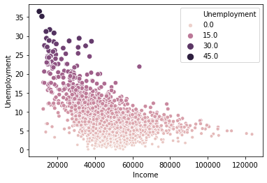

```python
sns.scatterplot(data=df_clean, x="Income", y="Unemployment", size = 'Unemployment', hue = 'Unemployment')
```

Counties w/ a lower Income tend to have a higher unemployment rate

### Pairplot on Sex

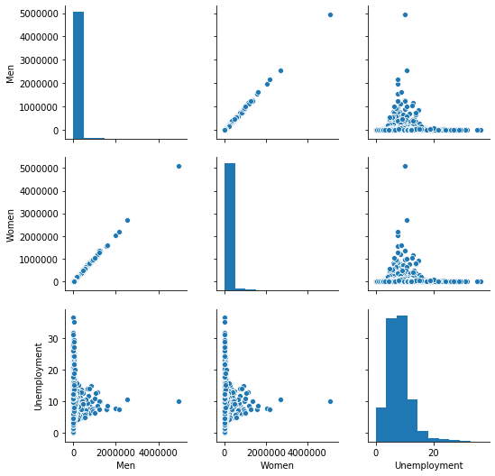

```python
sns.pairplot(df_clean[['Men', 'Women', 'Unemployment']])
```

#### Takeaway: It seems Gender does not have an impact on unemployment

### Pairplot on Ethnicity

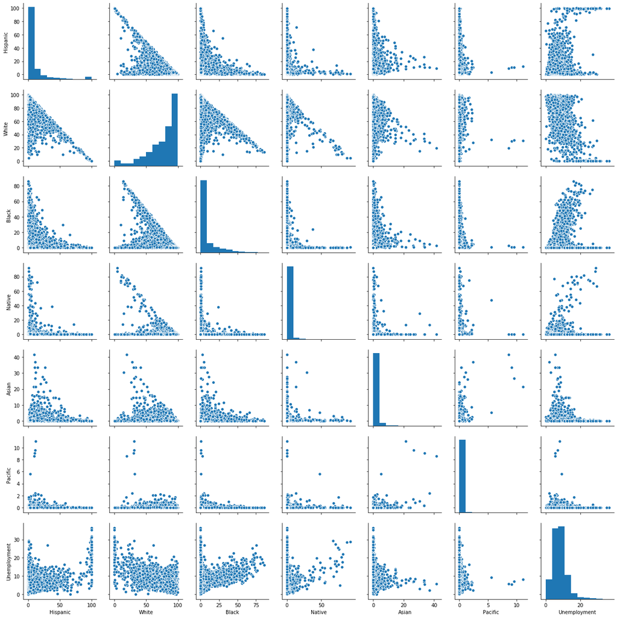

```python
sns.pairplot(df_clean[['Hispanic',
       'White', 'Black', 'Native', 'Asian', 'Pacific', 'Unemployment']])
```

### Pairplot on Occupation

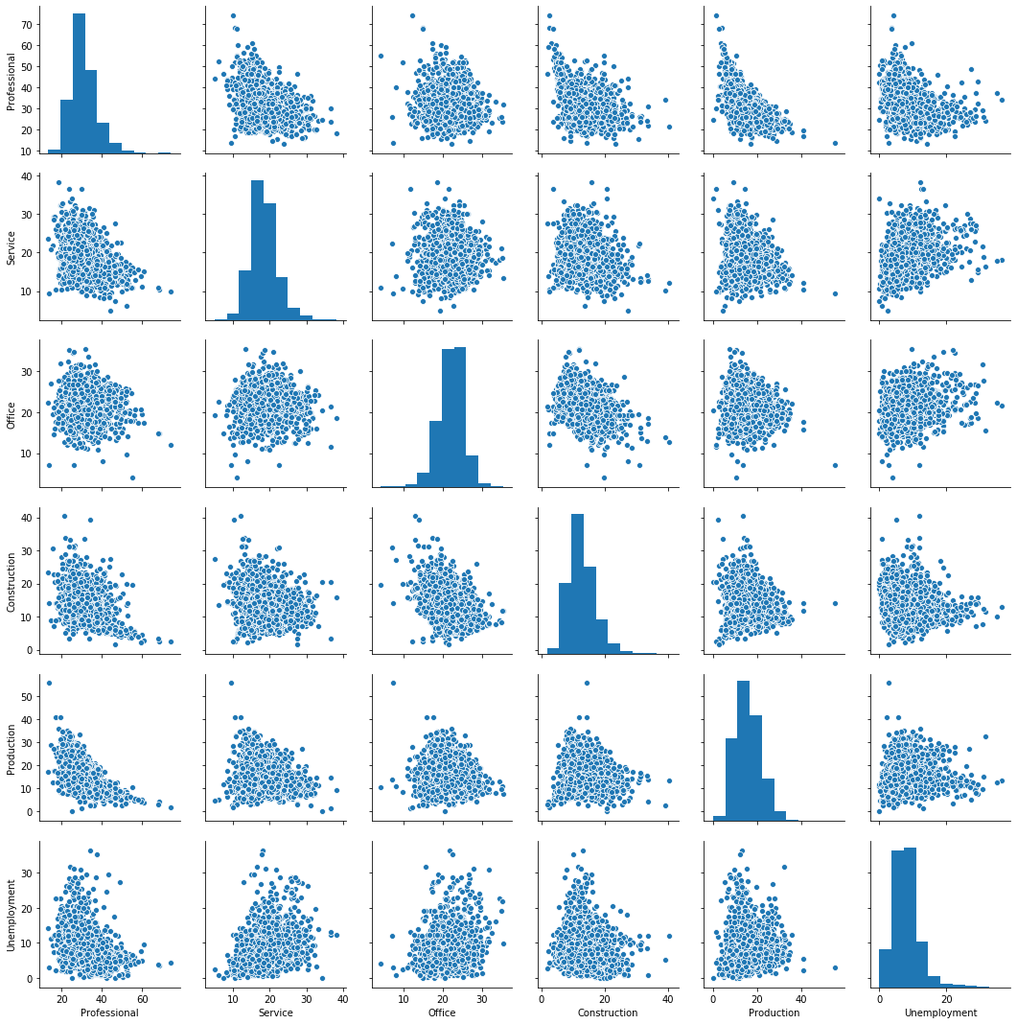

```python
sns.pairplot(df_clean[['Professional', 'Service', 'Office', 'Construction',
       'Production', 'Unemployment']])
```

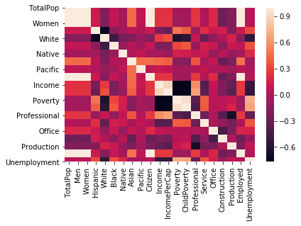

```python
sns.heatmap(df_clean.corr())
```

#### Based on the correlation heat map above, it seems like income, poverty, and occupation type are highly correlated

# Pivot Table on Sex vs County

```python
pivot = pd.pivot_table(data=df_clean,
                        columns=['County'],
                        values=['Men', 'Women', 'TotalPop'],
                        aggfunc = 'sum'
                        )
pivot.reindex(['Men', 'Women', 'TotalPop'])
```

| County | Abbeville | Acadia | Accomack | Ada | Adair | Adams | Addison | Adjuntas | Aguada | Aguadilla | ... | Yoakum | Yolo | York | Young | Yuba | Yukon-Koyukuk Census Area | Yuma | Zapata | Zavala | Ziebach |
| --- | --- | --- | --- | --- | --- | --- | --- | --- | --- | --- | --- | --- | --- | --- | --- | --- | --- | --- | --- | --- | --- |
| Men | 12308 | 30023 | 16117 | 208879 | 36220 | 409098 | 18355 | 9266 | 19912 | 28267 | ... | 4122 | 100937 | 469768 | 9158 | 37300 | 3038 | 108604 | 7153 | 5978 | 1391 |
| Women | 12689 | 32140 | 16998 | 208622 | 37854 | 406893 | 18588 | 9696 | 20691 | 29706 | ... | 4091 | 106383 | 489946 | 9171 | 36137 | 2606 | 104568 | 7155 | 6082 | 1442 |
| TotalPop | 24997 | 62163 | 33115 | 417501 | 74074 | 815991 | 36943 | 18962 | 40603 | 57973 | ... | 8213 | 207320 | 959714 | 18329 | 73437 | 5644 | 213172 | 14308 | 12060 | 2833 |

3 rows × 1928 columns

# Prepartion for Linear Regression Model

```python
x = df_clean[['TotalPop', 'Men', 'Women', 'Hispanic', 'White', 'Black', 'Native',
       'Asian', 'Pacific', 'Citizen', 'Income', 'IncomePerCap', 'Poverty',
       'ChildPoverty', 'Professional', 'Service', 'Office', 'Construction',
       'Production', 'Employed']]
y = df_clean[['Unemployment']]
```

# Ran into NaN Error

Need to drop NaN values

```python
df_clean.isna().sum()
```

```
TotalPop        0
Men             0
Women           0
Hispanic        0
White           0
Black           0
Native          0
Asian           0
Pacific         0
Citizen         0
Income          1
IncomePerCap    0
Poverty         0
ChildPoverty    1
Professional    0
Service         0
Office          0
Construction    0
Production      0
Employed        0
Unemployment    0
dtype: int64
```

```python
df_clean = df_clean.dropna()
```

```python
df_clean.isna().sum()
```

```
TotalPop        0
Men             0
Women           0
Hispanic        0
White           0
Black           0
Native          0
Asian           0
Pacific         0
Citizen         0
Income          0
IncomePerCap    0
Poverty         0
ChildPoverty    0
Professional    0
Service         0
Office          0
Construction    0
Production      0
Employed        0
Unemployment    0
dtype: int64
```

# Rechecking the Correlation

```python
df_clean.corr()['Unemployment'].sort_values(ascending=False)
```

```
Unemployment    1.000000
Poverty         0.712419
ChildPoverty    0.678441
Service         0.365371
Black           0.352943
Hispanic        0.321536
Native          0.187386
Office          0.161331
Production      0.079907
Citizen         0.031346
Women           0.031068
TotalPop        0.030313
Men             0.029522
Employed        0.014002
Pacific        -0.015888
Asian          -0.055315
Construction   -0.091779
Professional   -0.300318
Income         -0.509054
White          -0.540146
IncomePerCap   -0.547239
Name: Unemployment, dtype: float64
```

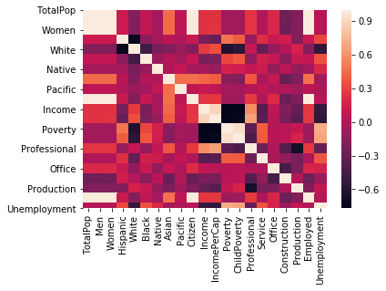

```python
sns.heatmap(df_clean.corr())
```

# Fitting the Linear Regression Model

```python
est = sm.OLS(y,x)
est2 = est.fit()
print(est2.summary())
```

```
                                 OLS Regression Results
=======================================================================================
Dep. Variable:           Unemployment   R-squared (uncentered):                   0.916
Model:                            OLS   Adj. R-squared (uncentered):              0.915
Method:                 Least Squares   F-statistic:                              1827.
Date:                Sun, 03 Apr 2022   Prob (F-statistic):                        0.00
Time:                        09:08:45   Log-Likelihood:                         -7683.9
No. Observations:                3218   AIC:                                  1.541e+04
Df Residuals:                    3199   BIC:                                  1.552e+04
Df Model:                          19
Covariance Type:            nonrobust
================================================================================
                   coef    std err          t      P>|t|      [0.025      0.975]
--------------------------------------------------------------------------------
TotalPop     -5.749e-07   1.92e-06     -0.300      0.764   -4.33e-06    3.18e-06
Men           1.568e-05   1.04e-05      1.501      0.134    -4.8e-06    3.62e-05
Women        -1.625e-05   1.06e-05     -1.527      0.127   -3.71e-05    4.62e-06
Hispanic         0.0076      0.032      0.233      0.815      -0.056       0.071
White            0.0018      0.033      0.054      0.957      -0.062       0.066
Black            0.0431      0.033      1.320      0.187      -0.021       0.107
Native           0.0734      0.035      2.074      0.038       0.004       0.143
Asian            0.0296      0.046      0.649      0.517      -0.060       0.119
Pacific         -0.1833      0.160     -1.147      0.251      -0.496       0.130
Citizen       1.853e-05   3.11e-06      5.965      0.000    1.24e-05    2.46e-05
Income        5.082e-05   9.71e-06      5.233      0.000    3.18e-05    6.99e-05
IncomePerCap -6.065e-05   2.04e-05     -2.969      0.003      -0.000   -2.06e-05
Poverty          0.3239      0.020     16.123      0.000       0.284       0.363
ChildPoverty    -0.0149      0.012     -1.211      0.226      -0.039       0.009
Professional    -0.0761      0.035     -2.200      0.028      -0.144      -0.008
Service          0.0732      0.034      2.141      0.032       0.006       0.140
Office           0.1101      0.035      3.162      0.002       0.042       0.178
Construction    -0.0531      0.035     -1.537      0.124      -0.121       0.015
Production       0.0136      0.034      0.394      0.693      -0.054       0.081
Employed     -2.177e-05   5.14e-06     -4.233      0.000   -3.19e-05   -1.17e-05
==============================================================================
Omnibus:                      298.199   Durbin-Watson:                   1.684
Prob(Omnibus):                  0.000   Jarque-Bera (JB):             1542.600
Skew:                           0.283   Prob(JB):                         0.00
Kurtosis:                       6.344   Cond. No.                     1.14e+16
==============================================================================

Warnings:
[1] Standard Errors assume that the covariance matrix of the errors is correctly specified.
[2] The smallest eigenvalue is 5.9e-18. This might indicate that there are
strong multicollinearity problems or that the design matrix is singular.
```

# We need to clean up the data some more. Some of these columns are not needed.

We will remove TotalPop & Employed

```python
#Rerun with TotalPop & Employed removed

x1 = df_clean[['Men', 'Women', 'Hispanic', 'White', 'Black', 'Native',
       'Asian', 'Pacific', 'Citizen', 'Income', 'IncomePerCap', 'Poverty',
       'ChildPoverty', 'Professional', 'Service', 'Office', 'Construction',
       'Production']]
y = df_clean[['Unemployment']]

est3 = sm.OLS(y,x1)
est4 = est3.fit()
print(est4.summary())
```

```
                                 OLS Regression Results
=======================================================================================
Dep. Variable:           Unemployment   R-squared (uncentered):                   0.915
Model:                            OLS   Adj. R-squared (uncentered):              0.915
Method:                 Least Squares   F-statistic:                              1917.
Date:                Sun, 03 Apr 2022   Prob (F-statistic):                        0.00
Time:                        10:18:32   Log-Likelihood:                         -7692.9
No. Observations:                3218   AIC:                                  1.542e+04
Df Residuals:                    3200   BIC:                                  1.553e+04
Df Model:                          18
Covariance Type:            nonrobust
================================================================================
                   coef    std err          t      P>|t|      [0.025      0.975]
--------------------------------------------------------------------------------
Men           4.095e-06   1.03e-05      0.398      0.691   -1.61e-05    2.43e-05
Women        -2.401e-05   1.11e-05     -2.169      0.030   -4.57e-05   -2.31e-06
Hispanic         0.0039      0.032      0.121      0.904      -0.060       0.068
White           -0.0028      0.033     -0.085      0.932      -0.067       0.062
Black            0.0387      0.033      1.182      0.237      -0.026       0.103
Native           0.0687      0.035      1.939      0.053      -0.001       0.138
Asian            0.0065      0.045      0.144      0.886      -0.082       0.095
Pacific         -0.1304      0.160     -0.817      0.414      -0.444       0.183
Citizen       1.693e-05   3.09e-06      5.477      0.000    1.09e-05     2.3e-05
Income        5.097e-05   9.74e-06      5.235      0.000    3.19e-05    7.01e-05
IncomePerCap -7.387e-05   2.02e-05     -3.650      0.000      -0.000   -3.42e-05
Poverty          0.3172      0.020     15.799      0.000       0.278       0.357
ChildPoverty    -0.0127      0.012     -1.032      0.302      -0.037       0.011
Professional    -0.0709      0.035     -2.047      0.041      -0.139      -0.003
Service          0.0849      0.034      2.486      0.013       0.018       0.152
Office           0.1236      0.035      3.554      0.000       0.055       0.192
Construction    -0.0461      0.035     -1.335      0.182      -0.114       0.022
Production       0.0190      0.034      0.552      0.581      -0.049       0.087
==============================================================================
Omnibus:                      289.920   Durbin-Watson:                   1.671
Prob(Omnibus):                  0.000   Jarque-Bera (JB):             1491.440
Skew:                           0.267   Prob(JB):                         0.00
Kurtosis:                       6.292   Cond. No.                     1.16e+06
==============================================================================

Warnings:
[1] Standard Errors assume that the covariance matrix of the errors is correctly specified.
[2] The condition number is large, 1.16e+06. This might indicate that there are
strong multicollinearity or other numerical problems.
```

# New Train Data Columns

```python
x1.columns
```

```
Index(['Men', 'Women', 'Hispanic', 'White', 'Black', 'Native', 'Asian',
       'Pacific', 'Citizen', 'Income', 'IncomePerCap', 'Poverty',
       'ChildPoverty', 'Professional', 'Service', 'Office', 'Construction',
       'Production'],
      dtype='object')
```

```python
x2 = df_clean[['TotalPop','Men', 'Women', 'Hispanic', 'White', 'Black', 'Native',
       'Asian', 'Pacific', 'Citizen', 'Income', 'IncomePerCap', 'Poverty',
       'ChildPoverty', 'Professional', 'Service', 'Office', 'Construction',
       'Production', 'Unemployment']]

# Changing integers to percent
x2['Men %'] = x2['Men']/x2['TotalPop']
x2['Women %'] = x2['Women']/x2['TotalPop']
x2['Citizen %'] = x2['Citizen']/x2['TotalPop']

# Race - floats to percent
x2['Hispanic'] = x2['Hispanic']/100
x2['White'] = x2['White']/100
x2['Black'] = x2['Black']/100
x2['Native'] = x2['Native']/100
x2['Pacific'] = x2['Pacific']/100

# Occupation Type - floats to percent
x2['Poverty'] = x2['Poverty']/100
x2['ChildPoverty'] = x2['ChildPoverty']/100
x2['Professional'] = x2['Professional']/100
x2['Service'] = x2['Service']/100
x2['Office'] = x2['Office']/100
x2['Construction'] = x2['Construction']/100
x2['Production'] = x2['Production']/100

# Unemployment - float to percent
x2['Unemployment'] = x2['Unemployment']/100

y2 = x2[['Unemployment']]
x2 = x2[['Men', 'Women', 'Hispanic', 'White', 'Black', 'Native',
       'Asian', 'Pacific', 'Citizen', 'Income', 'IncomePerCap', 'Poverty',
       'ChildPoverty', 'Professional', 'Service', 'Office', 'Construction',
       'Production']]
```

```python
est5 = sm.OLS(y,x2)
est6 = est5.fit()
print(est6.summary())
```

```
                                 OLS Regression Results
=======================================================================================
Dep. Variable:           Unemployment   R-squared (uncentered):                   0.915
Model:                            OLS   Adj. R-squared (uncentered):              0.915
Method:                 Least Squares   F-statistic:                              1917.
Date:                Sun, 03 Apr 2022   Prob (F-statistic):                        0.00
Time:                        11:34:16   Log-Likelihood:                         -7692.9
No. Observations:                3218   AIC:                                  1.542e+04
Df Residuals:                    3200   BIC:                                  1.553e+04
Df Model:                          18
Covariance Type:            nonrobust
================================================================================
                   coef    std err          t      P>|t|      [0.025      0.975]
--------------------------------------------------------------------------------
Men           4.095e-06   1.03e-05      0.398      0.691   -1.61e-05    2.43e-05
Women        -2.401e-05   1.11e-05     -2.169      0.030   -4.57e-05   -2.31e-06
Hispanic         0.3915      3.246      0.121      0.904      -5.972       6.755
White           -0.2785      3.283     -0.085      0.932      -6.715       6.158
Black            3.8713      3.275      1.182      0.237      -2.551      10.293
Native           6.8750      3.545      1.939      0.053      -0.076      13.826
Asian            0.0065      0.045      0.144      0.886      -0.082       0.095
Pacific        -13.0448     15.967     -0.817      0.414     -44.351      18.261
Citizen       1.693e-05   3.09e-06      5.477      0.000    1.09e-05     2.3e-05
Income        5.097e-05   9.74e-06      5.235      0.000    3.19e-05    7.01e-05
IncomePerCap -7.387e-05   2.02e-05     -3.650      0.000      -0.000   -3.42e-05
Poverty         31.7227      2.008     15.799      0.000      27.786      35.660
ChildPoverty    -1.2715      1.232     -1.032      0.302      -3.686       1.143
Professional    -7.0920      3.465     -2.047      0.041     -13.886      -0.298
Service          8.4915      3.416      2.486      0.013       1.793      15.190
Office          12.3559      3.477      3.554      0.000       5.539      19.172
Construction    -4.6148      3.457     -1.335      0.182     -11.394       2.164
Production       1.9036      3.448      0.552      0.581      -4.858       8.665
==============================================================================
Omnibus:                      289.920   Durbin-Watson:                   1.671
Prob(Omnibus):                  0.000   Jarque-Bera (JB):             1491.440
Skew:                           0.267   Prob(JB):                         0.00
Kurtosis:                       6.292   Cond. No.                     1.16e+08
==============================================================================

Warnings:
[1] Standard Errors assume that the covariance matrix of the errors is correctly specified.
[2] The condition number is large, 1.16e+08. This might indicate that there are
strong multicollinearity or other numerical problems.
```

# Takeaway from LR Model

We were hoping to use this model to run a test model on the US Census 2017 County data, however as shown above, the p-values indicate that some features are not as significant as we initially hypothesized.